# Suicide Rates in Finland - Exploration of Correlations

Milica Pajkic, Nuria Piller und Marco Rieder

2022-11-09

# 1. Introduction

Suicide is a complicated topic. And it is still a taboo in modern society. But not only does society struggle with understanding suicidal behavior - also scientists do so.

Studying suicide as a quantitative phenomenon can be especially paradoxical: Suicide is not frequent, and therefore it is hard to model.

> …in order to prevent suicide more effectively, we must increase the suicide rate. Only then will we be able to reduce the rate!

*David Lester, 1974, quoted in his essay about Qualitative Research in Suicidology (2010)*

Still, quantitative methods do what they can with what they have. [They go hand in hand with qualitative methods](https://www.ncbi.nlm.nih.gov/pmc/articles/PMC5598439/) to approach the topic of suicide, including a broad range of disciplines from clinical psychology to social sciences to literature. The complexity of examining suicide in a quantitative matter is what made us curious about it.

In this project, we will take a look at the suicide rates of Finland. Why Finland? Scandinavian countries are believed to have higher suicide rates than other European countries. Even though this belief [might not be statistically justified](https://nordics.info/show/artikel/is-suicide-more-common-in-the-nordics), it was enough to made us take a look at the [statistic page of Finland](https://www.stat.fi/index_en.html) and discover, that they have plenty of open source data we can use for our project.

Suicide is a sensible topic and needs to be addressed in an empathetic way. Behind each number and each case, is a story.

# 2. Descriptive Statistics

In order to be able to design models which actually make sense, we need some context about the topic itself. Hence, we start with very general descriptive statistics to get a broad overview about the topic. In this chapter, we want to answer to questions:

1. Did the relative number of suicides increase, considering population increases?
2. How does suicide relate to Gender and Age?

We will visualize the data in a graph:

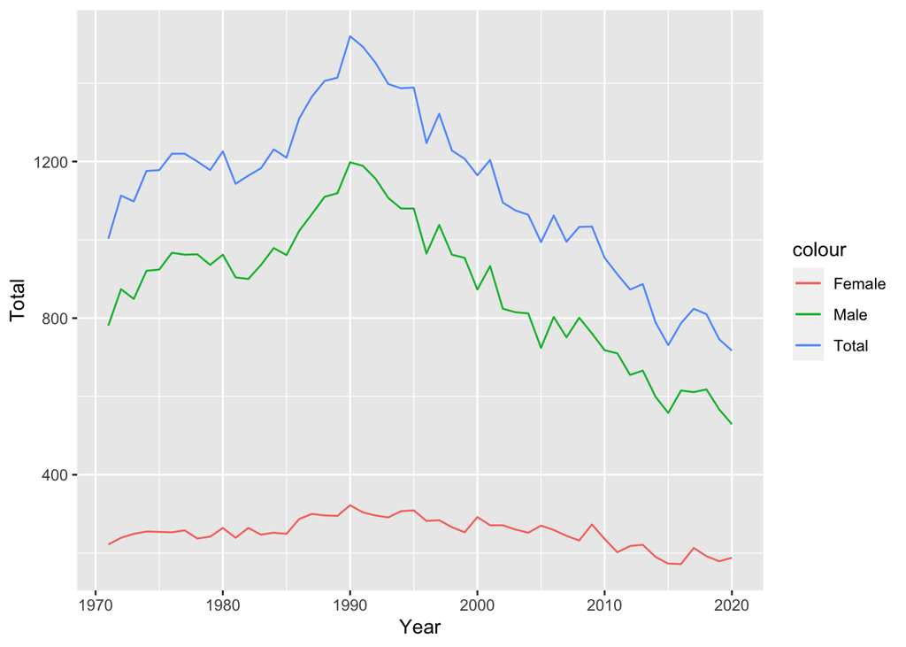

This graph already displays a lot of important information:

- Around 1990, there was a peak in suicides. Before the peak, the numbers were increasing, and after the peak, they are decreasing.
- In every point at time, the number of males were significantly higher than the number of females, who committed suicide.

Let us check how the population evolved during this period:

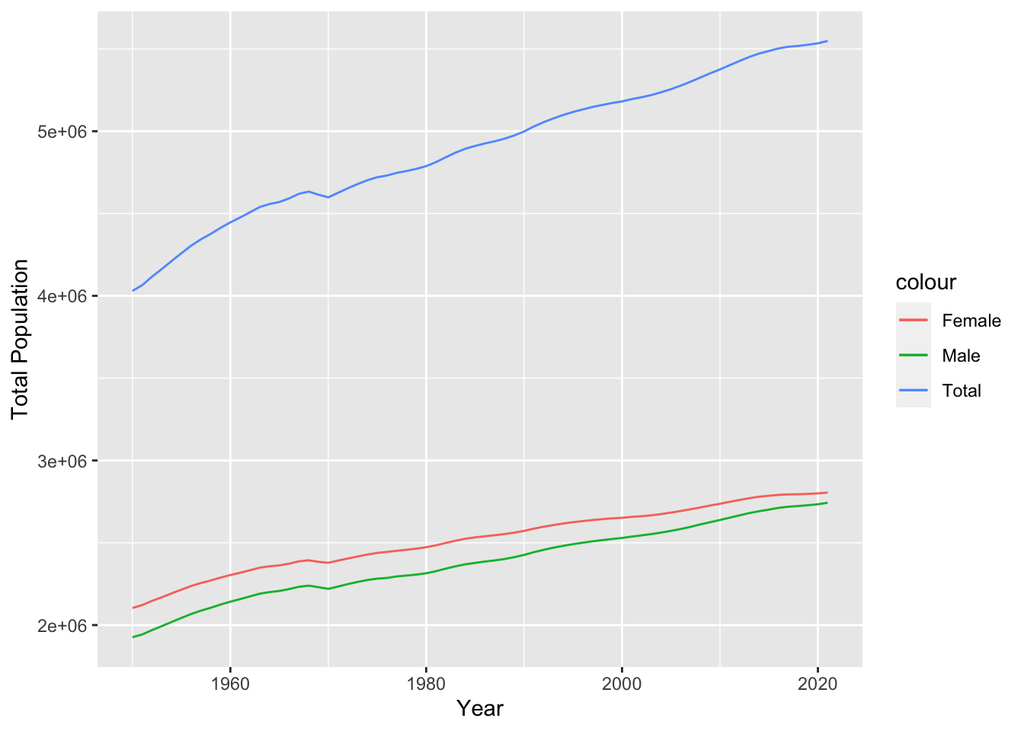

We can see that the population is growing in Finland. We therefore create another graph which shows the number of suicides per 100 000 inhabitants and compare if the trend looks similar.

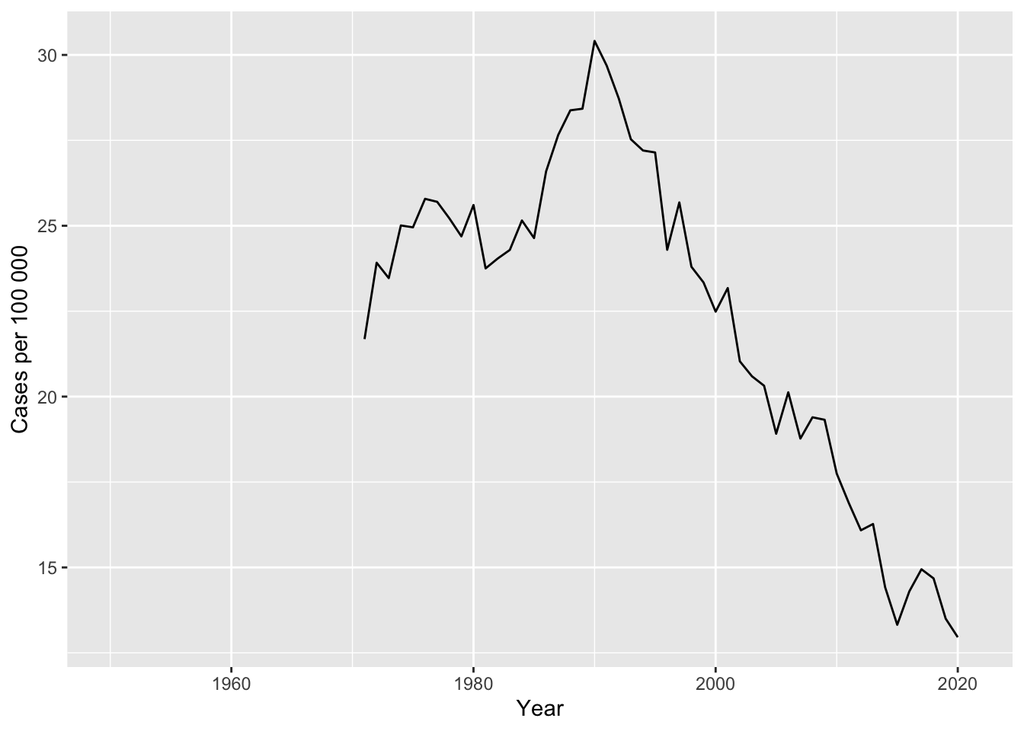

We now know that the suicide rates in Finland changed a lot since the 70ties - they were rising until the 90ties, and then decreasing. In the following chapters, we will use statistical methods and additional variables to explore eventual correlations.

### 2.2 Other possible explanation for suicide / context of the population at the time

#### Living costs

```
## # A tibble: 860 × 3
##    Year  Month `Point figure`
##    <chr> <chr> <chr>
##  1 1951  01    .
##  2 1951  02    .
##  3 1951  03    .
##  4 1951  04    .
##  5 1951  05    .
##  6 1951  06    .
##  7 1951  07    .
##  8 1951  08    .
##  9 1951  09    .
## 10 1951  10    100
## # … with 850 more rows
```

```
## [1] "character"
```

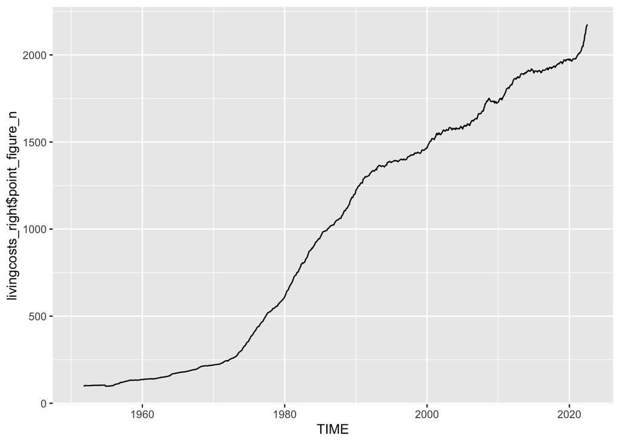

We see that around 1970+ there has been high rise in living costs. We should further consider **unemployment** at the same time.  
**What we can look at is maybe the percentage of living cost rise to the previous year.**

#### Employment

[output not shown]

[output cut: 395 more lines]

#### Unemployment

```
## # A tibble: 200 × 18
##    Year  Month Unemplo…¹ Unemp…² Unemp…³ Unemp…⁴ Unemp…⁵ Unemp…⁶ Unemp…⁷ Unemp…⁸
##    <chr> <chr>     <dbl>   <dbl>   <dbl>   <dbl>   <dbl>   <dbl>   <dbl>   <dbl>
##  1 2006  01       278486   12469   19023   28034   31970   20665   55155   25655
##  2 2006  02       268497   12820   16645   17424   32903   24667   54249   25250
##  3 2006  03       255527   11160   16341   17109   22952   24665   53447   25219
##  4 2006  04       246047   10522   16417   17495   23420   17478   50727   26874
##  5 2006  05       233816   11792   17392   17978   23706   14937   42995   24726
##  6 2006  06       258164   10555   21620   39080   25530   18884   38726   23456
##  7 2006  07       271231   11067   16489   25159   48534   20078   42797   25095
##  8 2006  08       240488   13241   18707   16397   22996   21743   45876   22338
##  9 2006  09       226113   10748   18591   21263   22764   13487   43810   19879
## 10 2006  10       225019   12838   17748   20486   26876   15190   40045   18200
## # … with 190 more rows, 8 more variables:
## #   `Unemployed jobseekers on calculation date (number) 40-52 weeks` <dbl>,
## #   `Unemployed jobseekers on calculation date (number) 53-78 weeks` <dbl>,
## #   `Unemployed jobseekers on calculation date (number) 79-104 weeks` <dbl>,
## #   `Unemployed jobseekers on calculation date (number) 2-3 years` <dbl>,
## #   `Unemployed jobseekers on calculation date (number) 3-4 years` <dbl>,
## #   `Unemployed jobseekers on calculation date (number) 4-5 years` <dbl>, …
```

```
## # A tibble: 200 × 19
##    Year  Month Unemplo…¹ Unemp…² Unemp…³ Unemp…⁴ Unemp…⁵ Unemp…⁶ Unemp…⁷ Unemp…⁸
##    <chr> <chr>     <dbl>   <dbl>   <dbl>   <dbl>   <dbl>   <dbl>   <dbl>   <dbl>
##  1 2006  01       278486   12469   19023   28034   31970   20665   55155   25655
##  2 2006  02       268497   12820   16645   17424   32903   24667   54249   25250
##  3 2006  03       255527   11160   16341   17109   22952   24665   53447   25219
##  4 2006  04       246047   10522   16417   17495   23420   17478   50727   26874
##  5 2006  05       233816   11792   17392   17978   23706   14937   42995   24726
##  6 2006  06       258164   10555   21620   39080   25530   18884   38726   23456
##  7 2006  07       271231   11067   16489   25159   48534   20078   42797   25095
##  8 2006  08       240488   13241   18707   16397   22996   21743   45876   22338
##  9 2006  09       226113   10748   18591   21263   22764   13487   43810   19879
## 10 2006  10       225019   12838   17748   20486   26876   15190   40045   18200
## # … with 190 more rows, 9 more variables:
## #   `Unemployed jobseekers on calculation date (number) 40-52 weeks` <dbl>,
## #   `Unemployed jobseekers on calculation date (number) 53-78 weeks` <dbl>,
## #   `Unemployed jobseekers on calculation date (number) 79-104 weeks` <dbl>,
## #   `Unemployed jobseekers on calculation date (number) 2-3 years` <dbl>,
## #   `Unemployed jobseekers on calculation date (number) 3-4 years` <dbl>,
## #   `Unemployed jobseekers on calculation date (number) 4-5 years` <dbl>, …
```

```
## [1] "double"
```

```
## # A tibble: 200 × 19
##    Year  Month  Total Unemploy…¹ Unemp…² Unemp…³ Unemp…⁴ Unemp…⁵ Unemp…⁶ Unemp…⁷
##    <chr> <chr>  <dbl>      <dbl>   <dbl>   <dbl>   <dbl>   <dbl>   <dbl>   <dbl>
##  1 2006  01    278486      12469   19023   28034   31970   20665   55155   25655
##  2 2006  02    268497      12820   16645   17424   32903   24667   54249   25250
##  3 2006  03    255527      11160   16341   17109   22952   24665   53447   25219
##  4 2006  04    246047      10522   16417   17495   23420   17478   50727   26874
##  5 2006  05    233816      11792   17392   17978   23706   14937   42995   24726
##  6 2006  06    258164      10555   21620   39080   25530   18884   38726   23456
##  7 2006  07    271231      11067   16489   25159   48534   20078   42797   25095
##  8 2006  08    240488      13241   18707   16397   22996   21743   45876   22338
##  9 2006  09    226113      10748   18591   21263   22764   13487   43810   19879
## 10 2006  10    225019      12838   17748   20486   26876   15190   40045   18200
## # … with 190 more rows, 9 more variables:
## #   `Unemployed jobseekers on calculation date (number) 40-52 weeks` <dbl>,
## #   `Unemployed jobseekers on calculation date (number) 53-78 weeks` <dbl>,
## #   `Unemployed jobseekers on calculation date (number) 79-104 weeks` <dbl>,
## #   `Unemployed jobseekers on calculation date (number) 2-3 years` <dbl>,
## #   `Unemployed jobseekers on calculation date (number) 3-4 years` <dbl>,
## #   `Unemployed jobseekers on calculation date (number) 4-5 years` <dbl>, …
```

Now let’s plot the data on unemployment. Because the data is categorically, we are going to do a bar plot

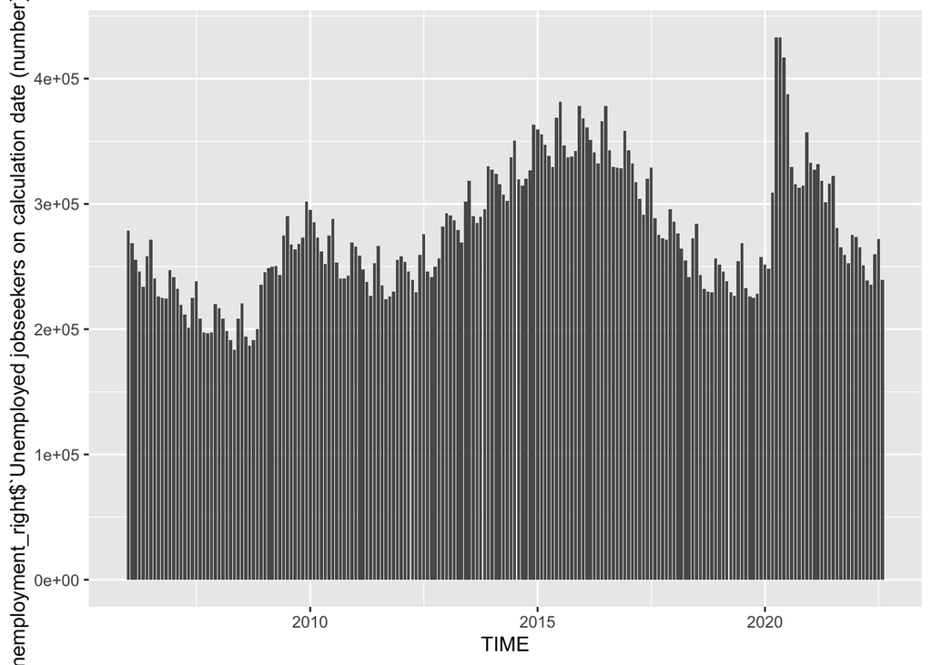

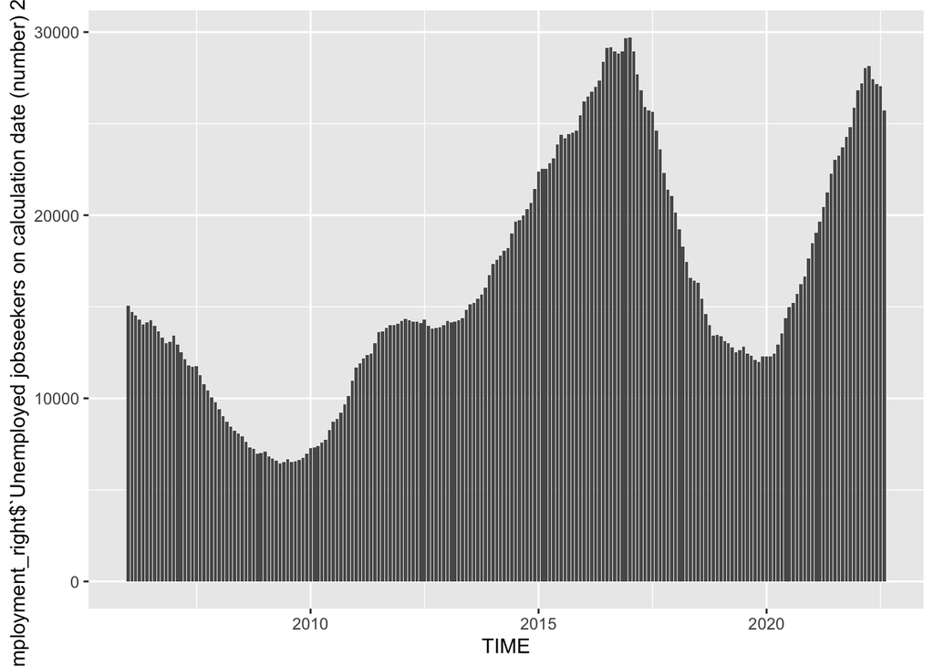

#### Bankruptcy

```
## # A tibble: 434 × 3
##    Year  Month `Bankruptcies instigated, number of employees`
##    <chr> <chr>                                          <dbl>
##  1 1986  01                                              1625
##  2 1986  02                                              1923
##  3 1986  03                                              1721
##  4 1986  04                                              1386
##  5 1986  05                                              1553
##  6 1986  06                                              1881
##  7 1986  07                                               980
##  8 1986  08                                              1428
##  9 1986  09                                              1138
## 10 1986  10                                              1963
## # … with 424 more rows
```

```
## # A tibble: 434 × 4
##    Year  Month `Bankruptcies instigated, number of employees` TIME
##    <chr> <chr>                                          <dbl> <date>
##  1 1986  01                                              1625 1986-01-01
##  2 1986  02                                              1923 1986-02-01
##  3 1986  03                                              1721 1986-03-01
##  4 1986  04                                              1386 1986-04-01
##  5 1986  05                                              1553 1986-05-01
##  6 1986  06                                              1881 1986-06-01
##  7 1986  07                                               980 1986-07-01
##  8 1986  08                                              1428 1986-08-01
##  9 1986  09                                              1138 1986-09-01
## 10 1986  10                                              1963 1986-10-01
## # … with 424 more rows
```

```
## Rows: 434
## Columns: 4
## $ Year                                           <chr> "1986", "1986", "1986",…
## $ Month                                          <chr> "01", "02", "03", "04",…
## $ `Bankruptcies instigated, number of employees` <dbl> 1625, 1923, 1721, 1386,…
## $ TIME                                           <date> 1986-01-01, 1986-02-01…
```

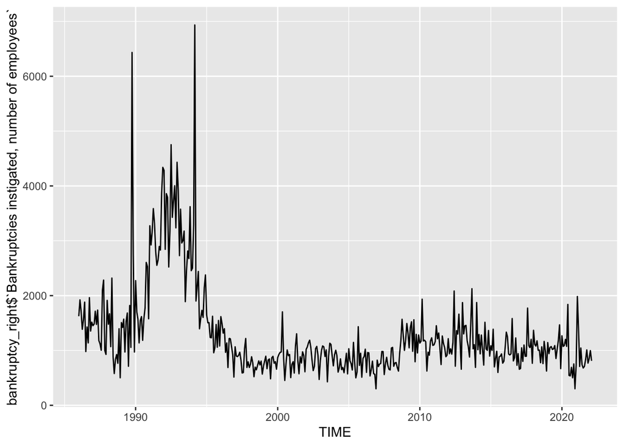

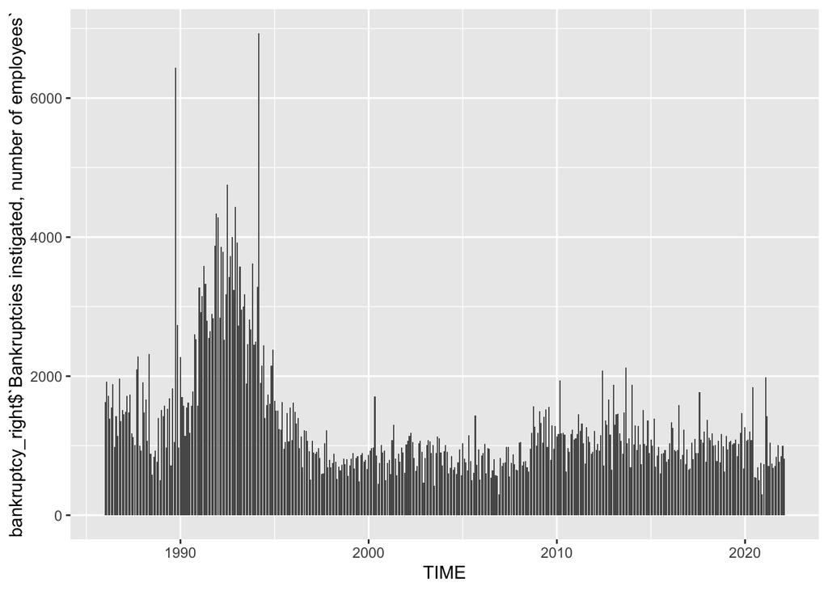

One thing we could look at is the **difference** to the previous year/month

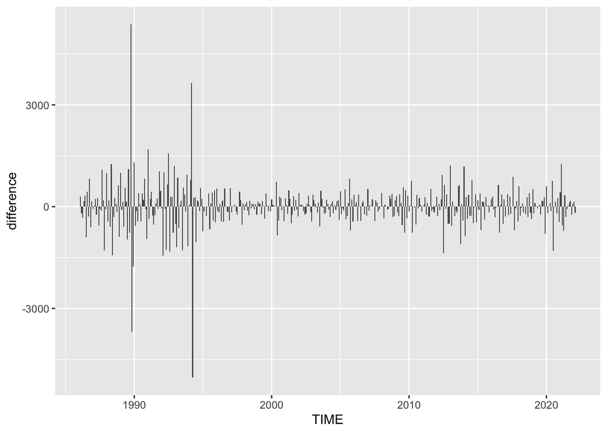

```
##     Min.  1st Qu.   Median     Mean  3rd Qu.     Max.     NA's
## -5034.00  -240.00    14.00    -1.88   233.00  5378.00        1
```

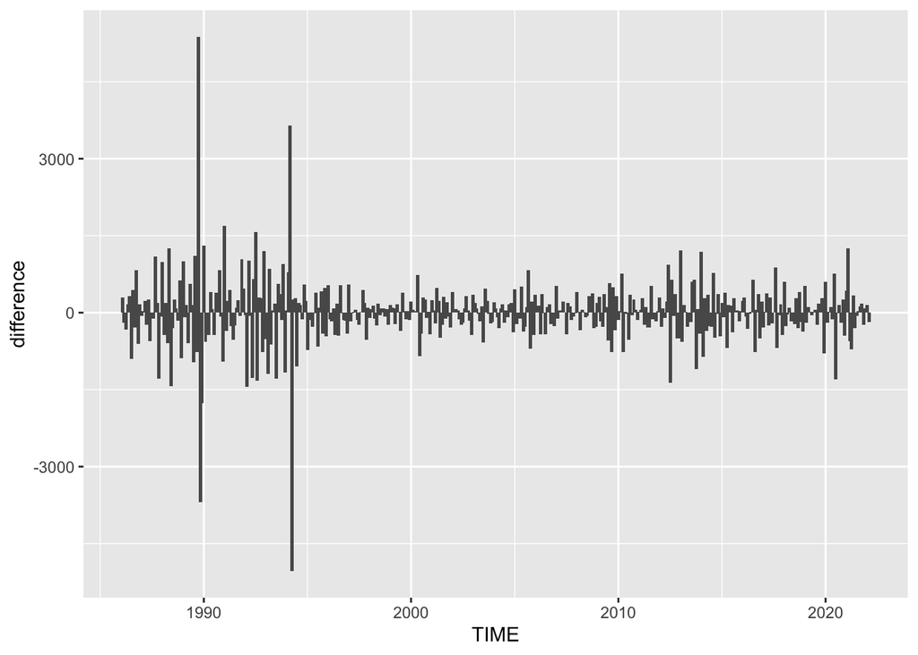